# Project: Investigate a Dataset - [Soccer-Database]

## Introduction

### Dataset Description

This soccer database comes from Kaggle and is well suited for data analysis and machine learning. It contains data for soccer matches, players, and teams from several European countries from 2008 to 2016.This dataset is quite extensive .

● The database is stored in a SQLite database. You can access database files using soware like DB Browser.

● This dataset will help you get good practice with your SQL joins. Make sure to look at how the dierent tables relate to each other.

● Some column titles should be self-explanatory, and others you’ll have to look up on Kaggle.

### Question(s) for Analysis

● What teams improved the most over the time period?

● Which players had the most penalties?

● What team attributes lead to the most victories?

```python
import pandas as pd
import numpy as np
import matplotlib.pyplot as plt
import seaborn as snb
%matplotlib inline
```

set up import statements for all of the packages that we plan to use.

```python
!pip install --upgrade pandas==0.25.0
```

## Data Wrangling

In this section of the report, you will load in the data, check for cleanliness, and then trim and clean your dataset for analysis.

Load our data and print out a few lines. Perform operations to inspect data.

```python
df1=pd.read_csv('Player_Attributes.csv')
df1.head()
```

|  | id | player_fifa_api_id | player_api_id | date | overall_rating | potential | preferred_foot | attacking_work_rate | defensive_work_rate | crossing | ... | vision | penalties | marking | standing_tackle | sliding_tackle | gk_diving | gk_handling | gk_kicking | gk_positioning | gk_reflexes |
| --- | --- | --- | --- | --- | --- | --- | --- | --- | --- | --- | --- | --- | --- | --- | --- | --- | --- | --- | --- | --- | --- |
| 0 | 1 | 218353 | 505942 | 2016-02-18 00:00:00 | 67.0 | 71.0 | right | medium | medium | 49.0 | ... | 54.0 | 48.0 | 65.0 | 69.0 | 69.0 | 6.0 | 11.0 | 10.0 | 8.0 | 8.0 |
| 1 | 2 | 218353 | 505942 | 2015-11-19 00:00:00 | 67.0 | 71.0 | right | medium | medium | 49.0 | ... | 54.0 | 48.0 | 65.0 | 69.0 | 69.0 | 6.0 | 11.0 | 10.0 | 8.0 | 8.0 |
| 2 | 3 | 218353 | 505942 | 2015-09-21 00:00:00 | 62.0 | 66.0 | right | medium | medium | 49.0 | ... | 54.0 | 48.0 | 65.0 | 66.0 | 69.0 | 6.0 | 11.0 | 10.0 | 8.0 | 8.0 |
| 3 | 4 | 218353 | 505942 | 2015-03-20 00:00:00 | 61.0 | 65.0 | right | medium | medium | 48.0 | ... | 53.0 | 47.0 | 62.0 | 63.0 | 66.0 | 5.0 | 10.0 | 9.0 | 7.0 | 7.0 |
| 4 | 5 | 218353 | 505942 | 2007-02-22 00:00:00 | 61.0 | 65.0 | right | medium | medium | 48.0 | ... | 53.0 | 47.0 | 62.0 | 63.0 | 66.0 | 5.0 | 10.0 | 9.0 | 7.0 | 7.0 |

5 rows × 42 columns

```python
df2=pd.read_csv("Match.csv")
df2.head()
```

|  | id | country_id | league_id | season | stage | date | match_api_id | home_team_api_id | away_team_api_id | home_team_goal | ... | SJA | VCH | VCD | VCA | GBH | GBD | GBA | BSH | BSD | BSA |
| --- | --- | --- | --- | --- | --- | --- | --- | --- | --- | --- | --- | --- | --- | --- | --- | --- | --- | --- | --- | --- | --- |
| 0 | 1 | 1 | 1 | 2008/2009 | 1 | 2008-08-17 00:00:00 | 492473 | 9987 | 9993 | 1 | ... | 4.00 | 1.65 | 3.40 | 4.50 | 1.78 | 3.25 | 4.00 | 1.73 | 3.40 | 4.20 |
| 1 | 2 | 1 | 1 | 2008/2009 | 1 | 2008-08-16 00:00:00 | 492474 | 10000 | 9994 | 0 | ... | 3.80 | 2.00 | 3.25 | 3.25 | 1.85 | 3.25 | 3.75 | 1.91 | 3.25 | 3.60 |
| 2 | 3 | 1 | 1 | 2008/2009 | 1 | 2008-08-16 00:00:00 | 492475 | 9984 | 8635 | 0 | ... | 2.50 | 2.35 | 3.25 | 2.65 | 2.50 | 3.20 | 2.50 | 2.30 | 3.20 | 2.75 |
| 3 | 4 | 1 | 1 | 2008/2009 | 1 | 2008-08-17 00:00:00 | 492476 | 9991 | 9998 | 5 | ... | 7.50 | 1.45 | 3.75 | 6.50 | 1.50 | 3.75 | 5.50 | 1.44 | 3.75 | 6.50 |
| 4 | 5 | 1 | 1 | 2008/2009 | 1 | 2008-08-16 00:00:00 | 492477 | 7947 | 9985 | 1 | ... | 1.73 | 4.50 | 3.40 | 1.65 | 4.50 | 3.50 | 1.65 | 4.75 | 3.30 | 1.67 |

5 rows × 115 columns

```python
df3=pd.read_csv('Team_Attributes.csv')
df3.head()
```

|  | id | team_fifa_api_id | team_api_id | date | buildUpPlaySpeed | buildUpPlaySpeedClass | buildUpPlayDribbling | buildUpPlayDribblingClass | buildUpPlayPassing | buildUpPlayPassingClass | ... | chanceCreationShooting | chanceCreationShootingClass | chanceCreationPositioningClass | defencePressure | defencePressureClass | defenceAggression | defenceAggressionClass | defenceTeamWidth | defenceTeamWidthClass | defenceDefenderLineClass |
| --- | --- | --- | --- | --- | --- | --- | --- | --- | --- | --- | --- | --- | --- | --- | --- | --- | --- | --- | --- | --- | --- |
| 0 | 1 | 434 | 9930 | 2010-02-22 00:00:00 | 60 | Balanced | NaN | Little | 50 | Mixed | ... | 55 | Normal | Organised | 50 | Medium | 55 | Press | 45 | Normal | Cover |
| 1 | 2 | 434 | 9930 | 2014-09-19 00:00:00 | 52 | Balanced | 48.0 | Normal | 56 | Mixed | ... | 64 | Normal | Organised | 47 | Medium | 44 | Press | 54 | Normal | Cover |
| 2 | 3 | 434 | 9930 | 2015-09-10 00:00:00 | 47 | Balanced | 41.0 | Normal | 54 | Mixed | ... | 64 | Normal | Organised | 47 | Medium | 44 | Press | 54 | Normal | Cover |
| 3 | 4 | 77 | 8485 | 2010-02-22 00:00:00 | 70 | Fast | NaN | Little | 70 | Long | ... | 70 | Lots | Organised | 60 | Medium | 70 | Double | 70 | Wide | Cover |
| 4 | 5 | 77 | 8485 | 2011-02-22 00:00:00 | 47 | Balanced | NaN | Little | 52 | Mixed | ... | 52 | Normal | Organised | 47 | Medium | 47 | Press | 52 | Normal | Cover |

5 rows × 25 columns

```python
df1.shape
```

```
(183978, 42)
```

```python
df2.shape
```

```
(25979, 115)
```

```python
df3.shape
```

```
(1458, 25)
```

```python
df1.duplicated().sum()
```

```
0
```

There is not duplicate rows in Player Attributes csv.

```python
df2.duplicated().sum()
```

```
0
```

There is not duplicate rows in Match csv.

```python
df3.duplicated().sum()
```

```
0
```

There is not duplicate rows in Teams Attributes csv.

```python
df1.isnull().sum()
```

```
id                        0
player_fifa_api_id        0
player_api_id             0
date                      0
overall_rating          836
potential               836
preferred_foot          836
attacking_work_rate    3230
defensive_work_rate     836
crossing                836
finishing               836
heading_accuracy        836
short_passing           836
volleys                2713
dribbling               836
curve                  2713
free_kick_accuracy      836
long_passing            836
ball_control            836
acceleration            836
sprint_speed            836
agility                2713
reactions               836
balance                2713
shot_power              836
jumping                2713
stamina                 836
strength                836
long_shots              836
aggression              836
interceptions           836
positioning             836
vision                 2713
penalties               836
marking                 836
standing_tackle         836
sliding_tackle         2713
gk_diving               836
gk_handling             836
gk_kicking              836
gk_positioning          836
gk_reflexes             836
dtype: int64
```

There is missing data in Player Attributes csv.

```python
df2.isnull().sum()
```

```
id                0
country_id        0
league_id         0
season            0
stage             0
              ...
GBD           11817
GBA           11817
BSH           11818
BSD           11818
BSA           11818
Length: 115, dtype: int64
```

There is missing data in Match csv.

```python
df3.isnull().sum()
```

```
id                                  0
team_fifa_api_id                    0
team_api_id                         0
date                                0
buildUpPlaySpeed                    0
buildUpPlaySpeedClass               0
buildUpPlayDribbling              969
buildUpPlayDribblingClass           0
buildUpPlayPassing                  0
buildUpPlayPassingClass             0
buildUpPlayPositioningClass         0
chanceCreationPassing               0
chanceCreationPassingClass          0
chanceCreationCrossing              0
chanceCreationCrossingClass         0
chanceCreationShooting              0
chanceCreationShootingClass         0
chanceCreationPositioningClass      0
defencePressure                     0
defencePressureClass                0
defenceAggression                   0
defenceAggressionClass              0
defenceTeamWidth                    0
defenceTeamWidthClass               0
defenceDefenderLineClass            0
dtype: int64
```

There is missing data in Teams Attributes csv.

```python
df1.info()
```

```
<class 'pandas.core.frame.DataFrame'>
RangeIndex: 183978 entries, 0 to 183977
Data columns (total 42 columns):
id                     183978 non-null int64
player_fifa_api_id     183978 non-null int64
player_api_id          183978 non-null int64
date                   183978 non-null object
overall_rating         183142 non-null float64
potential              183142 non-null float64
preferred_foot         183142 non-null object
attacking_work_rate    180748 non-null object
defensive_work_rate    183142 non-null object
crossing               183142 non-null float64
finishing              183142 non-null float64
heading_accuracy       183142 non-null float64
short_passing          183142 non-null float64
volleys                181265 non-null float64
dribbling              183142 non-null float64
curve                  181265 non-null float64
free_kick_accuracy     183142 non-null float64
long_passing           183142 non-null float64
ball_control           183142 non-null float64
acceleration           183142 non-null float64
sprint_speed           183142 non-null float64
agility                181265 non-null float64
reactions              183142 non-null float64
balance                181265 non-null float64
shot_power             183142 non-null float64
jumping                181265 non-null float64
stamina                183142 non-null float64
strength               183142 non-null float64
long_shots             183142 non-null float64
aggression             183142 non-null float64
interceptions          183142 non-null float64
positioning            183142 non-null float64
vision                 181265 non-null float64
penalties              183142 non-null float64
marking                183142 non-null float64
standing_tackle        183142 non-null float64
sliding_tackle         181265 non-null float64
gk_diving              183142 non-null float64
gk_handling            183142 non-null float64
gk_kicking             183142 non-null float64
gk_positioning         183142 non-null float64
gk_reflexes            183142 non-null float64
dtypes: float64(35), int64(3), object(4)
memory usage: 59.0+ MB
```

```python
df2.info()
```

```
<class 'pandas.core.frame.DataFrame'>
RangeIndex: 25979 entries, 0 to 25978
Columns: 115 entries, id to BSA
dtypes: float64(96), int64(9), object(10)
memory usage: 22.8+ MB
```

```python
df3.info()
```

```
<class 'pandas.core.frame.DataFrame'>
RangeIndex: 1458 entries, 0 to 1457
Data columns (total 25 columns):
id                                1458 non-null int64
team_fifa_api_id                  1458 non-null int64
team_api_id                       1458 non-null int64
date                              1458 non-null object
buildUpPlaySpeed                  1458 non-null int64
buildUpPlaySpeedClass             1458 non-null object
buildUpPlayDribbling              489 non-null float64
buildUpPlayDribblingClass         1458 non-null object
buildUpPlayPassing                1458 non-null int64
buildUpPlayPassingClass           1458 non-null object
buildUpPlayPositioningClass       1458 non-null object
chanceCreationPassing             1458 non-null int64
chanceCreationPassingClass        1458 non-null object
chanceCreationCrossing            1458 non-null int64
chanceCreationCrossingClass       1458 non-null object
chanceCreationShooting            1458 non-null int64
chanceCreationShootingClass       1458 non-null object
chanceCreationPositioningClass    1458 non-null object
defencePressure                   1458 non-null int64
defencePressureClass              1458 non-null object
defenceAggression                 1458 non-null int64
defenceAggressionClass            1458 non-null object
defenceTeamWidth                  1458 non-null int64
defenceTeamWidthClass             1458 non-null object
defenceDefenderLineClass          1458 non-null object
dtypes: float64(1), int64(11), object(13)
memory usage: 284.9+ KB
```

```python
df1.describe()
```

|  | id | player_fifa_api_id | player_api_id | overall_rating | potential | crossing | finishing | heading_accuracy | short_passing | volleys | ... | vision | penalties | marking | standing_tackle | sliding_tackle | gk_diving | gk_handling | gk_kicking | gk_positioning | gk_reflexes |
| --- | --- | --- | --- | --- | --- | --- | --- | --- | --- | --- | --- | --- | --- | --- | --- | --- | --- | --- | --- | --- | --- |
| count | 183978.00000 | 183978.000000 | 183978.000000 | 183142.000000 | 183142.000000 | 183142.000000 | 183142.000000 | 183142.000000 | 183142.000000 | 181265.000000 | ... | 181265.000000 | 183142.000000 | 183142.000000 | 183142.000000 | 181265.000000 | 183142.000000 | 183142.000000 | 183142.000000 | 183142.000000 | 183142.000000 |
| mean | 91989.50000 | 165671.524291 | 135900.617324 | 68.600015 | 73.460353 | 55.086883 | 49.921078 | 57.266023 | 62.429672 | 49.468436 | ... | 57.873550 | 55.003986 | 46.772242 | 50.351257 | 48.001462 | 14.704393 | 16.063612 | 20.998362 | 16.132154 | 16.441439 |
| std | 53110.01825 | 53851.094769 | 136927.840510 | 7.041139 | 6.592271 | 17.242135 | 19.038705 | 16.488905 | 14.194068 | 18.256618 | ... | 15.144086 | 15.546519 | 21.227667 | 21.483706 | 21.598778 | 16.865467 | 15.867382 | 21.452980 | 16.099175 | 17.198155 |
| min | 1.00000 | 2.000000 | 2625.000000 | 33.000000 | 39.000000 | 1.000000 | 1.000000 | 1.000000 | 3.000000 | 1.000000 | ... | 1.000000 | 2.000000 | 1.000000 | 1.000000 | 2.000000 | 1.000000 | 1.000000 | 1.000000 | 1.000000 | 1.000000 |
| 25% | 45995.25000 | 155798.000000 | 34763.000000 | 64.000000 | 69.000000 | 45.000000 | 34.000000 | 49.000000 | 57.000000 | 35.000000 | ... | 49.000000 | 45.000000 | 25.000000 | 29.000000 | 25.000000 | 7.000000 | 8.000000 | 8.000000 | 8.000000 | 8.000000 |
| 50% | 91989.50000 | 183488.000000 | 77741.000000 | 69.000000 | 74.000000 | 59.000000 | 53.000000 | 60.000000 | 65.000000 | 52.000000 | ... | 60.000000 | 57.000000 | 50.000000 | 56.000000 | 53.000000 | 10.000000 | 11.000000 | 12.000000 | 11.000000 | 11.000000 |
| 75% | 137983.75000 | 199848.000000 | 191080.000000 | 73.000000 | 78.000000 | 68.000000 | 65.000000 | 68.000000 | 72.000000 | 64.000000 | ... | 69.000000 | 67.000000 | 66.000000 | 69.000000 | 67.000000 | 13.000000 | 15.000000 | 15.000000 | 15.000000 | 15.000000 |
| max | 183978.00000 | 234141.000000 | 750584.000000 | 94.000000 | 97.000000 | 95.000000 | 97.000000 | 98.000000 | 97.000000 | 93.000000 | ... | 97.000000 | 96.000000 | 96.000000 | 95.000000 | 95.000000 | 94.000000 | 93.000000 | 97.000000 | 96.000000 | 96.000000 |

8 rows × 38 columns

```python
df2.describe()
```

|  | id | country_id | league_id | stage | match_api_id | home_team_api_id | away_team_api_id | home_team_goal | away_team_goal | home_player_X1 | ... | SJA | VCH | VCD | VCA | GBH | GBD | GBA | BSH | BSD | BSA |
| --- | --- | --- | --- | --- | --- | --- | --- | --- | --- | --- | --- | --- | --- | --- | --- | --- | --- | --- | --- | --- | --- |
| count | 25979.000000 | 25979.000000 | 25979.000000 | 25979.000000 | 2.597900e+04 | 25979.000000 | 25979.000000 | 25979.000000 | 25979.000000 | 24158.000000 | ... | 17097.000000 | 22568.000000 | 22568.000000 | 22568.000000 | 14162.000000 | 14162.000000 | 14162.000000 | 14161.000000 | 14161.000000 | 14161.000000 |
| mean | 12990.000000 | 11738.630317 | 11738.630317 | 18.242773 | 1.195429e+06 | 9984.371993 | 9984.475115 | 1.544594 | 1.160938 | 0.999586 | ... | 4.622343 | 2.668107 | 3.899048 | 4.840281 | 2.498764 | 3.648189 | 4.353097 | 2.497894 | 3.660742 | 4.405663 |
| std | 7499.635658 | 7553.936759 | 7553.936759 | 10.407354 | 4.946279e+05 | 14087.453758 | 14087.445135 | 1.297158 | 1.142110 | 0.022284 | ... | 3.632164 | 1.928753 | 1.248221 | 4.318338 | 1.489299 | 0.867440 | 3.010189 | 1.507793 | 0.868272 | 3.189814 |
| min | 1.000000 | 1.000000 | 1.000000 | 1.000000 | 4.831290e+05 | 1601.000000 | 1601.000000 | 0.000000 | 0.000000 | 0.000000 | ... | 1.100000 | 1.030000 | 1.620000 | 1.080000 | 1.050000 | 1.450000 | 1.120000 | 1.040000 | 1.330000 | 1.120000 |
| 25% | 6495.500000 | 4769.000000 | 4769.000000 | 9.000000 | 7.684365e+05 | 8475.000000 | 8475.000000 | 1.000000 | 0.000000 | 1.000000 | ... | 2.500000 | 1.700000 | 3.300000 | 2.550000 | 1.670000 | 3.200000 | 2.500000 | 1.670000 | 3.250000 | 2.500000 |
| 50% | 12990.000000 | 10257.000000 | 10257.000000 | 18.000000 | 1.147511e+06 | 8697.000000 | 8697.000000 | 1.000000 | 1.000000 | 1.000000 | ... | 3.500000 | 2.150000 | 3.500000 | 3.500000 | 2.100000 | 3.300000 | 3.400000 | 2.100000 | 3.400000 | 3.400000 |
| 75% | 19484.500000 | 17642.000000 | 17642.000000 | 27.000000 | 1.709852e+06 | 9925.000000 | 9925.000000 | 2.000000 | 2.000000 | 1.000000 | ... | 5.250000 | 2.800000 | 4.000000 | 5.400000 | 2.650000 | 3.750000 | 5.000000 | 2.620000 | 3.750000 | 5.000000 |
| max | 25979.000000 | 24558.000000 | 24558.000000 | 38.000000 | 2.216672e+06 | 274581.000000 | 274581.000000 | 10.000000 | 9.000000 | 2.000000 | ... | 41.000000 | 36.000000 | 26.000000 | 67.000000 | 21.000000 | 11.000000 | 34.000000 | 17.000000 | 13.000000 | 34.000000 |

8 rows × 105 columns

```python
df3.describe()
```

|  | id | team_fifa_api_id | team_api_id | buildUpPlaySpeed | buildUpPlayDribbling | buildUpPlayPassing | chanceCreationPassing | chanceCreationCrossing | chanceCreationShooting | defencePressure | defenceAggression | defenceTeamWidth |
| --- | --- | --- | --- | --- | --- | --- | --- | --- | --- | --- | --- | --- |
| count | 1458.000000 | 1458.000000 | 1458.000000 | 1458.000000 | 489.000000 | 1458.000000 | 1458.000000 | 1458.000000 | 1458.000000 | 1458.000000 | 1458.000000 | 1458.000000 |
| mean | 729.500000 | 17706.982167 | 9995.727023 | 52.462277 | 48.607362 | 48.490398 | 52.165295 | 53.731824 | 53.969136 | 46.017147 | 49.251029 | 52.185871 |
| std | 421.032659 | 39179.857739 | 13264.869900 | 11.545869 | 9.678290 | 10.896101 | 10.360793 | 11.086796 | 10.327566 | 10.227225 | 9.738028 | 9.574712 |
| min | 1.000000 | 1.000000 | 1601.000000 | 20.000000 | 24.000000 | 20.000000 | 21.000000 | 20.000000 | 22.000000 | 23.000000 | 24.000000 | 29.000000 |
| 25% | 365.250000 | 110.000000 | 8457.750000 | 45.000000 | 42.000000 | 40.000000 | 46.000000 | 47.000000 | 48.000000 | 39.000000 | 44.000000 | 47.000000 |
| 50% | 729.500000 | 485.000000 | 8674.000000 | 52.000000 | 49.000000 | 50.000000 | 52.000000 | 53.000000 | 53.000000 | 45.000000 | 48.000000 | 52.000000 |
| 75% | 1093.750000 | 1900.000000 | 9904.000000 | 62.000000 | 55.000000 | 55.000000 | 59.000000 | 62.000000 | 61.000000 | 51.000000 | 55.000000 | 58.000000 |
| max | 1458.000000 | 112513.000000 | 274581.000000 | 80.000000 | 77.000000 | 80.000000 | 80.000000 | 80.000000 | 80.000000 | 72.000000 | 72.000000 | 73.000000 |

```python
df1.duplicated(['date','player_api_id']).sum()
```

```
836
```

There is 836 duplicate data in colunms:date and player api id in player attributes csv .

```python
df2.duplicated(['date','match_api_id','home_team_api_id']).sum()
```

```
0
```

There is not duplicate data in colunms:date , match api id and home api id in match csv .

```python
df3.duplicated(['date','team_fifa_api_id','team_api_id']).sum()
```

```
1
```

There is 1 duplicate data in colunms:date , team fifa api id and team api id in teams attributes csv .

```python
df3['team_fifa_api_id'].nunique()
```

```
285
```

There is 285 teams in Teams Attributes csv.

### Data Cleaning

in this section : We will prepare the data For the data exploration phase .

```python
df1.dropna(inplace=True)
df1.isna().sum()
```

```
id                     0
player_fifa_api_id     0
player_api_id          0
date                   0
overall_rating         0
potential              0
preferred_foot         0
attacking_work_rate    0
defensive_work_rate    0
crossing               0
finishing              0
heading_accuracy       0
short_passing          0
volleys                0
dribbling              0
curve                  0
free_kick_accuracy     0
long_passing           0
ball_control           0
acceleration           0
sprint_speed           0
agility                0
reactions              0
balance                0
shot_power             0
jumping                0
stamina                0
strength               0
long_shots             0
aggression             0
interceptions          0
positioning            0
vision                 0
penalties              0
marking                0
standing_tackle        0
sliding_tackle         0
gk_diving              0
gk_handling            0
gk_kicking             0
gk_positioning         0
gk_reflexes            0
dtype: int64
```

In Player Attributes Csv There Is No Missing Data.

```python
df1.shape
```

```
(180354, 42)
```

Records Is Decreased after Deleted Cells which Contain Missing Data.

```python
df2.dropna(inplace=True)
df2.isna().sum()
```

```
id            0
country_id    0
league_id     0
season        0
stage         0
             ..
GBD           0
GBA           0
BSH           0
BSD           0
BSA           0
Length: 115, dtype: int64
```

In Match Csv There Is No Missing Data.

```python
df2.shape
```

```
(1762, 115)
```

Records Is Decreased after Deleted Cells which Contain Missing Data.

```python
df3.dropna(inplace=True)
df3.isna().sum()
```

```
id                                0
team_fifa_api_id                  0
team_api_id                       0
date                              0
buildUpPlaySpeed                  0
buildUpPlaySpeedClass             0
buildUpPlayDribbling              0
buildUpPlayDribblingClass         0
buildUpPlayPassing                0
buildUpPlayPassingClass           0
buildUpPlayPositioningClass       0
chanceCreationPassing             0
chanceCreationPassingClass        0
chanceCreationCrossing            0
chanceCreationCrossingClass       0
chanceCreationShooting            0
chanceCreationShootingClass       0
chanceCreationPositioningClass    0
defencePressure                   0
defencePressureClass              0
defenceAggression                 0
defenceAggressionClass            0
defenceTeamWidth                  0
defenceTeamWidthClass             0
defenceDefenderLineClass          0
dtype: int64
```

In teams Attributes Csv There Is No Missing Data.

```python
df3.shape
```

```
(489, 25)
```

Records Is Decreased after Deleted Cells which Contain Missing Data.

```python
df1.drop_duplicates(['date','player_api_id'],inplace=True)
df1.shape
```

```
(180354, 42)
```

Number of rows and colunms in Player Attributes do not change because duplicate data in colunms:date and player api id was missing data .

```python
df3.drop_duplicates(['date','team_fifa_api_id','team_api_id'],inplace=True)
df3.shape
```

```
(488, 25)
```

We Deleted Duplicates Data In Teams Attributes Csv .

```python
df1.drop(['player_api_id','gk_reflexes','gk_positioning','gk_kicking','gk_handling','gk_diving','sliding_tackle','marking'],axis=1,inplace=True)
df1.head()
```

|  | id | player_fifa_api_id | date | overall_rating | potential | preferred_foot | attacking_work_rate | defensive_work_rate | crossing | finishing | ... | jumping | stamina | strength | long_shots | aggression | interceptions | positioning | vision | penalties | standing_tackle |
| --- | --- | --- | --- | --- | --- | --- | --- | --- | --- | --- | --- | --- | --- | --- | --- | --- | --- | --- | --- | --- | --- |
| 0 | 1 | 218353 | 2016-02-18 00:00:00 | 67.0 | 71.0 | right | medium | medium | 49.0 | 44.0 | ... | 58.0 | 54.0 | 76.0 | 35.0 | 71.0 | 70.0 | 45.0 | 54.0 | 48.0 | 69.0 |
| 1 | 2 | 218353 | 2015-11-19 00:00:00 | 67.0 | 71.0 | right | medium | medium | 49.0 | 44.0 | ... | 58.0 | 54.0 | 76.0 | 35.0 | 71.0 | 70.0 | 45.0 | 54.0 | 48.0 | 69.0 |
| 2 | 3 | 218353 | 2015-09-21 00:00:00 | 62.0 | 66.0 | right | medium | medium | 49.0 | 44.0 | ... | 58.0 | 54.0 | 76.0 | 35.0 | 63.0 | 41.0 | 45.0 | 54.0 | 48.0 | 66.0 |
| 3 | 4 | 218353 | 2015-03-20 00:00:00 | 61.0 | 65.0 | right | medium | medium | 48.0 | 43.0 | ... | 58.0 | 54.0 | 76.0 | 34.0 | 62.0 | 40.0 | 44.0 | 53.0 | 47.0 | 63.0 |
| 4 | 5 | 218353 | 2007-02-22 00:00:00 | 61.0 | 65.0 | right | medium | medium | 48.0 | 43.0 | ... | 58.0 | 54.0 | 76.0 | 34.0 | 62.0 | 40.0 | 44.0 | 53.0 | 47.0 | 63.0 |

5 rows × 34 columns

We Deleted Columns Which Will Not Help Us Analysis The Data .

```python
df2.drop(['home_player_X1','home_player_X2','home_player_X3','home_player_X4','home_player_X5','home_player_X6','home_player_X7','home_player_X8','home_player_X9','home_player_X10','home_player_X11','away_player_X1','away_player_X2','away_player_X3','away_player_X4','away_player_X5','away_player_X6','away_player_X7','away_player_X8','away_player_X9','away_player_X10','away_player_X11','home_player_Y1','home_player_Y2','home_player_Y3','home_player_Y4','home_player_Y5','home_player_Y6','home_player_Y7','home_player_Y8','home_player_Y9','home_player_Y10','home_player_Y11','away_player_Y1','away_player_Y2','away_player_Y3','away_player_Y4','away_player_Y5','away_player_Y6','away_player_Y7','away_player_Y8','away_player_Y9','away_player_Y10','away_player_Y11','home_player_1','home_player_2','home_player_3','home_player_4','home_player_5','home_player_6','home_player_7','home_player_8','home_player_9','home_player_10','home_player_11','away_player_1','away_player_2','away_player_3','away_player_4','away_player_5','away_player_6','away_player_7','away_player_8','away_player_9','away_player_10','away_player_11','SJA','VCH','VCD','VCA','GBH','GBD','PSA','WHH','WHD','SJH','SJD','GBA','BSH','BSD','BSA','B365H','B365D','B365A','BWH','BWD','BWA','IWH','IWD','IWA','LBH','LBD','LBA','PSH','PSD'],axis=1,inplace=True)
df2.head(3)
```

|  | id | country_id | league_id | season | stage | date | match_api_id | home_team_api_id | away_team_api_id | home_team_goal | away_team_goal | goal | shoton | shotoff | foulcommit | card | cross | corner | possession | WHA |
| --- | --- | --- | --- | --- | --- | --- | --- | --- | --- | --- | --- | --- | --- | --- | --- | --- | --- | --- | --- | --- |
| 3248 | 3249 | 1729 | 1729 | 2012/2013 | 1 | 2012-08-18 00:00:00 | 1228229 | 9825 | 8472 | 0 | 0 | <goal /> | <shoton><value><stats><shoton>1</shoton></stat... | <shotoff><value><stats><shotoff>1</shotoff></s... | <foulcommit><value><stats><foulscommitted>1</f... | <card /> | <cross><value><stats><crosses>1</crosses></sta... | <corner><value><stats><corners>1</corners></st... | <possession><value><comment>52</comment><event... | 8.00 |
| 3249 | 3250 | 1729 | 1729 | 2012/2013 | 1 | 2012-08-20 00:00:00 | 1228230 | 8668 | 10260 | 1 | 0 | <goal><value><comment>n</comment><stats><goals... | <shoton><value><stats><shoton>1</shoton></stat... | <shotoff><value><stats><shotoff>1</shotoff></s... | <foulcommit><value><stats><foulscommitted>1</f... | <card><value><comment>y</comment><stats><ycard... | <cross><value><stats><crosses>1</crosses></sta... | <corner><value><stats><corners>1</corners></st... | <possession><value><comment>32</comment><event... | 1.91 |
| 3250 | 3251 | 1729 | 1729 | 2012/2013 | 1 | 2012-08-18 00:00:00 | 1228231 | 9879 | 9850 | 5 | 0 | <goal><value><comment>n</comment><stats><goals... | <shoton><value><stats><shoton>1</shoton></stat... | <shotoff><value><stats><shotoff>1</shotoff></s... | <foulcommit><value><stats><foulscommitted>1</f... | <card /> | <cross><value><stats><crosses>1</crosses></sta... | <corner><value><stats><corners>1</corners></st... | <possession><value><comment>58</comment><event... | 4.50 |

Deleted Columns Which Will Not Help Us Analysis The Data .

```python
df3.drop(['team_api_id','buildUpPlaySpeedClass','buildUpPlayDribblingClass','buildUpPlayPassingClass','buildUpPlayPositioningClass','chanceCreationShootingClass','chanceCreationPositioningClass','defencePressureClass','defenceAggressionClass','defenceTeamWidthClass','defenceDefenderLineClass'],axis=1,inplace=True)
df3.head()
```

|  | id | team_fifa_api_id | date | buildUpPlaySpeed | buildUpPlayDribbling | buildUpPlayPassing | chanceCreationPassing | chanceCreationPassingClass | chanceCreationCrossing | chanceCreationCrossingClass | chanceCreationShooting | defencePressure | defenceAggression | defenceTeamWidth |
| --- | --- | --- | --- | --- | --- | --- | --- | --- | --- | --- | --- | --- | --- | --- |
| 1 | 2 | 434 | 2014-09-19 00:00:00 | 52 | 48.0 | 56 | 54 | Normal | 63 | Normal | 64 | 47 | 44 | 54 |
| 2 | 3 | 434 | 2015-09-10 00:00:00 | 47 | 41.0 | 54 | 54 | Normal | 63 | Normal | 64 | 47 | 44 | 54 |
| 7 | 8 | 77 | 2014-09-19 00:00:00 | 58 | 64.0 | 62 | 56 | Normal | 68 | Lots | 57 | 41 | 42 | 60 |
| 8 | 9 | 77 | 2015-09-10 00:00:00 | 59 | 64.0 | 53 | 51 | Normal | 72 | Lots | 63 | 49 | 45 | 63 |
| 13 | 14 | 614 | 2014-09-19 00:00:00 | 59 | 57.0 | 52 | 48 | Normal | 38 | Normal | 52 | 38 | 47 | 53 |

We Deleted Columns Which Will Not Help Us Analysis The Data .

## Exploratory Data Analysis

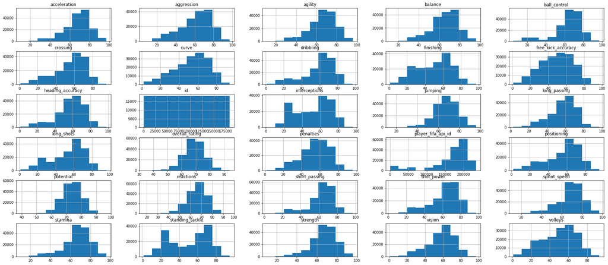

```python
df1.hist(figsize=(30,13));
```

The frequancy for each label.

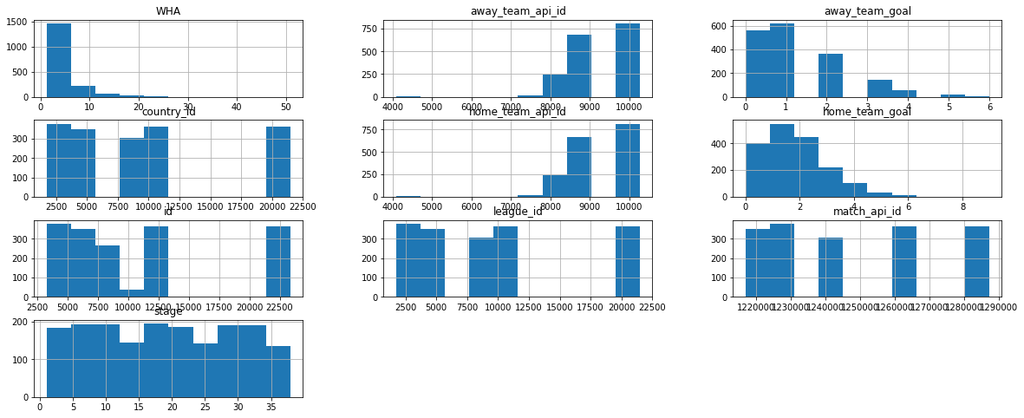

```python
df2.hist(figsize=(20,8));
```

The frequancy for each label.

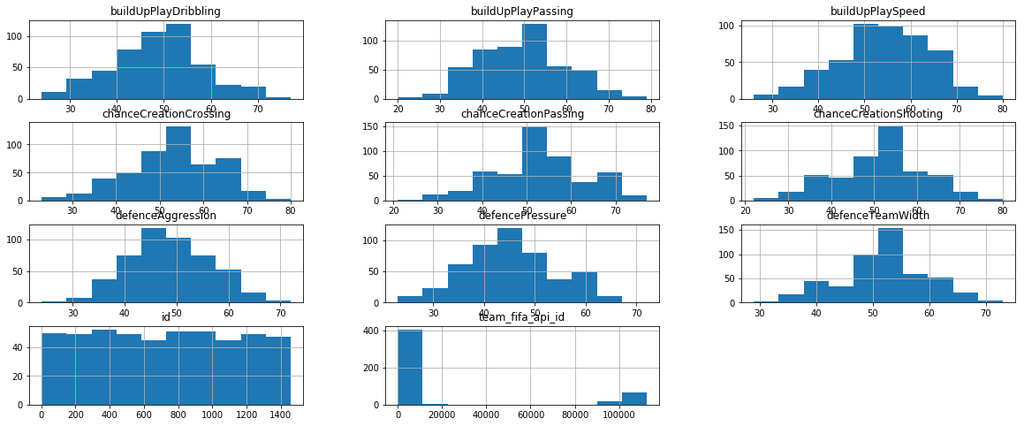

```python
df3.hist(figsize=(20,8));
```

The frequancy for each label.

### Research Question 1 (What teams improved the most over the time period?)

Answer this question will show level of the teams therefore, if there is a poorly performing team, the probability of disqualification, and if there is a good team, the probability of being rewarded.

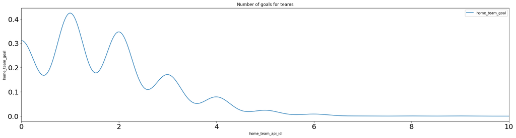

```python
def question (df,xcol_name,ycol_name,title,limx):
    df.sort_values(inplace=True,by=['date'],ascending=[True])
    df.plot(x=xcol_name,y=ycol_name,kind='kde',figsize=(25,6),fontsize=20,xlim=[0,limx]);
    plt.title(title)
    plt.xlabel(xcol_name)
    plt.ylabel(ycol_name)
    plt.legend();
    df.head()
question(df2,'home_team_api_id','home_team_goal','Number of goals for teams',10)
```

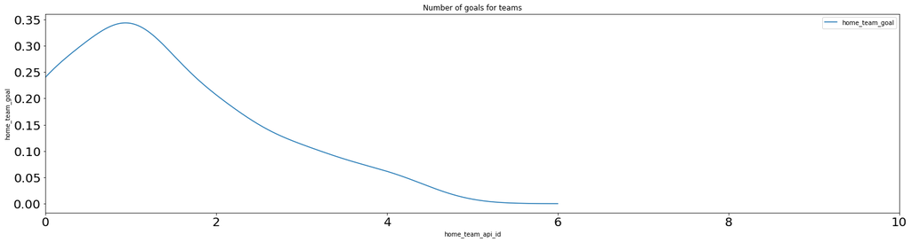

```python
df5=df2[df2['home_team_api_id']<8000]
question(df5,'home_team_api_id','home_team_goal','Number of goals for teams',10)
```

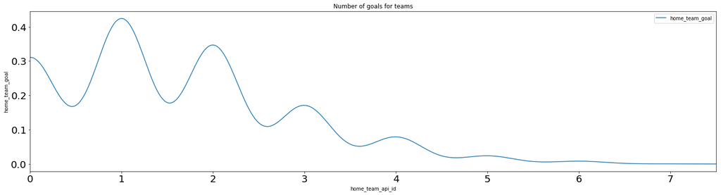

```python
df6=df2[df2['home_team_api_id']<14000]
question(df6,'home_team_api_id','home_team_goal','Number of goals for teams',7.5)
```

### Research Question 2 (Which players had the most penalties?)

Answer this question will show level of the players therefore, if there is a poorly performing player, the probability of disqualification, and if there is a good player, the probability of being rewardedrded.

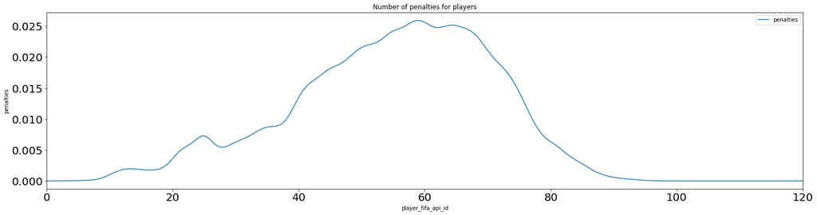

```python
question(df1,'player_fifa_api_id','penalties','Number of penalties for players',120)
```

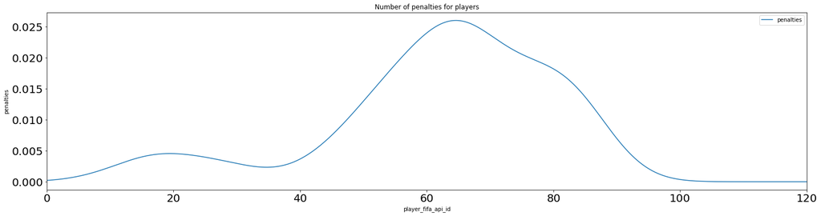

```python
df4=df1[df1['player_fifa_api_id']<90]
question(df4,'player_fifa_api_id','penalties','Number of penalties for players',120)
```

### Research Question 3 ( What team attributes lead to the most victories? )

Answer this question will show level of teams , if team attributes is good it is possible that he will qualify for another level or if team attributes is bad it is possible that he will qualify for out of order.

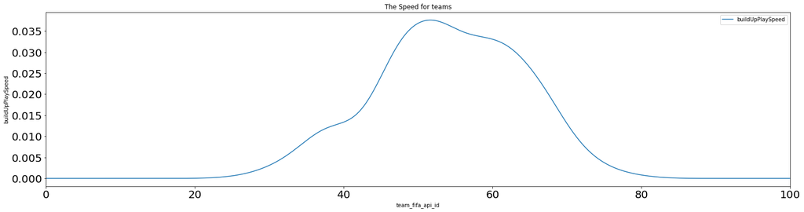

```python
question(df3,'team_fifa_api_id','buildUpPlaySpeed','The Speed for teams',100)
```

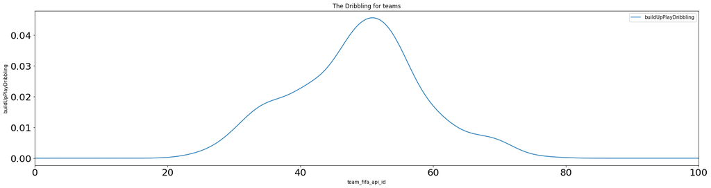

```python
question(df3,'team_fifa_api_id','buildUpPlayDribbling','The Dribbling for teams',100)
```

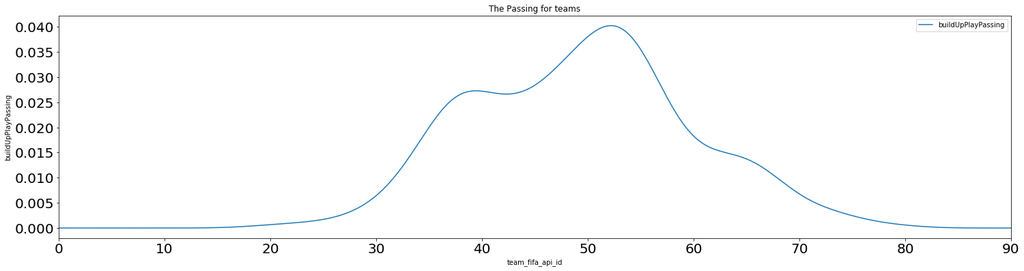

```python
question(df3,'team_fifa_api_id','buildUpPlayPassing','The Passing for teams',90)
```

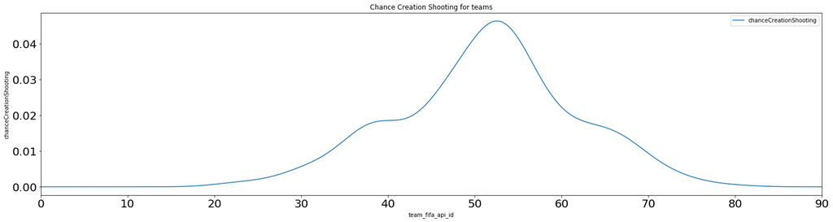

```python
question(df3,'team_fifa_api_id','chanceCreationShooting','Chance Creation Shooting for teams',90)
```

## Limitations

### There are some limitations with our data :

1. A lot of our variabals are categorical , which dose not allow for a high level of statistical method .
1. Some files are very big and inside of it alot of data do not help us in our analysis , Which took a lot of time to find out the important data that will benefit us in our analysis .

```python
from subprocess import call
call(['python', '-m', 'nbconvert', 'Investigate_a_Dataset.ipynb'])
```

```
0
```